# Some enhanced functions to evaluate the fitted model

TheSky0908

2023-10-25

(In this note, we reach a consensus that # of observations is $n$ and # of features (predictor variables) is $k$.)

### Import the dataset.

```r
library(base)
data(state)
force(state.x77)
states<-as.data.frame(state.x77[,c("Murder", "Population",
                                   "Illiteracy", "Income", "Frost")])
```

### Scatter plot matrix

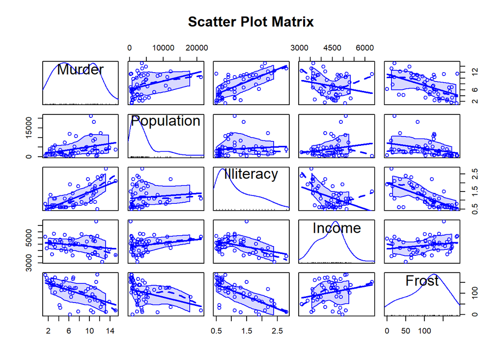

```r
library(car)
scatterplotMatrix(states,spread=FALSE, lty.smooth=2,main="Scatter Plot Matrix")
```

Figures on the diagonal line show the density plot of each predictors; other figures show the scatter plots between predictors.

### Fit a linear model and standard diagnostic plots

```r
fit <- lm(Murder ~ Population + Illiteracy + Income + Frost,
          data=states)
summary(fit)
```

```
##
## Call:
## lm(formula = Murder ~ Population + Illiteracy + Income + Frost,
##     data = states)
##
## Residuals:
##     Min      1Q  Median      3Q     Max
## -4.7960 -1.6495 -0.0811  1.4815  7.6210
##
## Coefficients:
##              Estimate Std. Error t value Pr(>|t|)
## (Intercept) 1.235e+00  3.866e+00   0.319   0.7510
## Population  2.237e-04  9.052e-05   2.471   0.0173 *
## Illiteracy  4.143e+00  8.744e-01   4.738 2.19e-05 ***
## Income      6.442e-05  6.837e-04   0.094   0.9253
## Frost       5.813e-04  1.005e-02   0.058   0.9541
## ---
## Signif. codes:  0 '***' 0.001 '**' 0.01 '*' 0.05 '.' 0.1 ' ' 1
##
## Residual standard error: 2.535 on 45 degrees of freedom
## Multiple R-squared:  0.567,  Adjusted R-squared:  0.5285
## F-statistic: 14.73 on 4 and 45 DF,  p-value: 9.133e-08
```

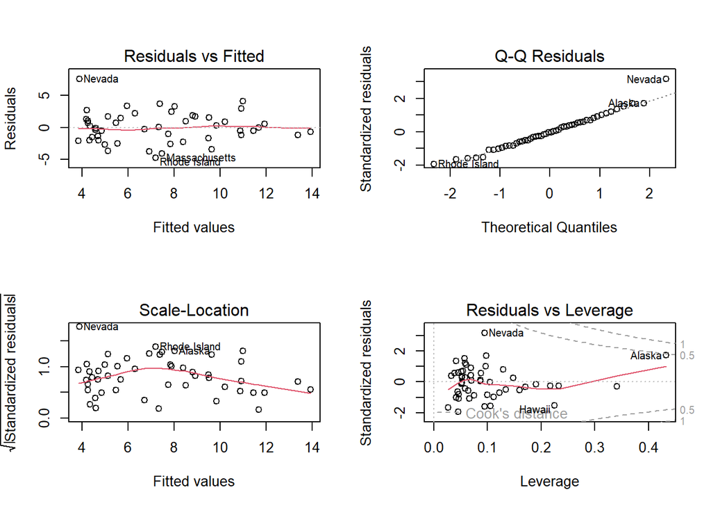

```r
par(mfrow = c(2,2))
plot(fit)
```

### Test normality of residuals

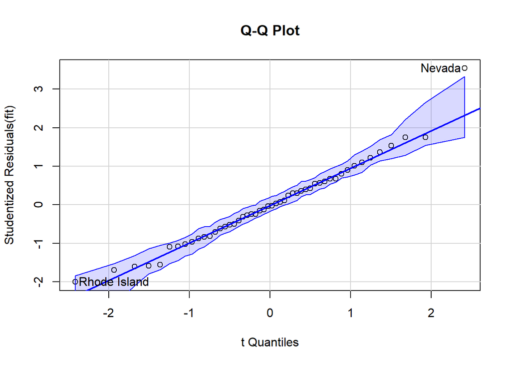

```
##       Nevada Rhode Island
##           28           39
```

```r
library(car)

fit <- lm(Murder ~ Population + Illiteracy + Income + Frost, data=states)
qqPlot(fit, labels=row.names(states), id.method="identify",
       simulate=TRUE, main="Q-Q Plot")
```

If the simulated line is approximately close to $y = x$, then we can maintain the residual is normally distributed.

From the figure above, we can discover that residuals of Nevada and Rhode Island tend to be larger, then they are possibly outliers.

Next, we show another method to visualized residuals.

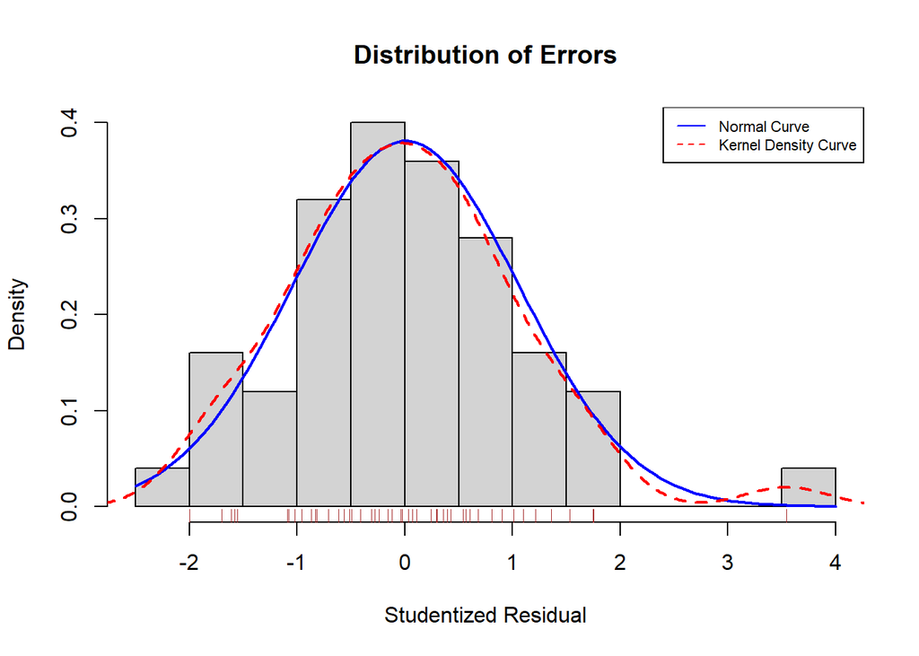

```r
residplot <- function(fit, nbreaks=10) {
  z <- rstudent(fit)
  hist(z, breaks=nbreaks, freq=FALSE,
       xlab="Studentized Residual",
       main="Distribution of Errors")
  rug(jitter(z), col="brown")
  curve(dnorm(x, mean=mean(z), sd=sd(z)),
        add=TRUE, col="blue", lwd=2)
  lines(density(z)$x, density(z)$y,
        col="red", lwd=2, lty=2)
  legend("topright",
         legend = c( "Normal Curve", "Kernel Density Curve"),
         lty=1:2, col=c("blue","red"), cex=.7)
}

residplot(fit)
```

### Test independence of residuals

```r
durbinWatsonTest(fit)
```

```
##  lag Autocorrelation D-W Statistic p-value
##    1      -0.2006929      2.317691   0.272
##  Alternative hypothesis: rho != 0
```

### Test linearity

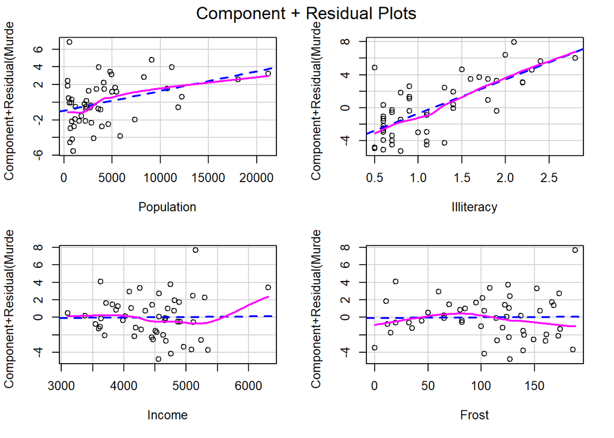

```r
library(car)
crPlots(fit)
```

The $X_k$ partial residual can be thought of as the response variable $Y$ corrected for all predictor variables except $X_k$.

The linear model is
$$Y = \beta_0 +
\beta_1 X_1 + \cdots + \beta_{k-1}X_{k-1} + \beta_kX_k
+\varepsilon.$$

Then the $X_k$ partial residual is defined as
$$e_{X_k} \triangleq \varepsilon +
\beta_kX_k = Y - \beta_0 - \beta_1 X_1 - \cdots -
\beta_{k-1}X_{k-1}.$$

The component plus residual plot is so called “Partial residual plot”, which is the scatter plots composed of $(X_k,e_{X_k})$. Since the nonlinear relation between $Y$ and $X_k$ is described in the $\varepsilon$ generated by OLS, then we can obtain the extent and direction of linearity between $Y$ and $X_k$ by the scatter plot of $X_k$ partial residual $e_{X_k}$ and $X_k$ itself.

If the component plus residual plot shows a linear relation, then we maintain that linear assumption is met and the form of linear model seems to be appropriate for the dataset.

### Test homoscedasticity

```r
library(car)
ncvTest(fit)
```

```
## Non-constant Variance Score Test
## Variance formula: ~ fitted.values
## Chisquare = 1.746514, Df = 1, p = 0.18632
```

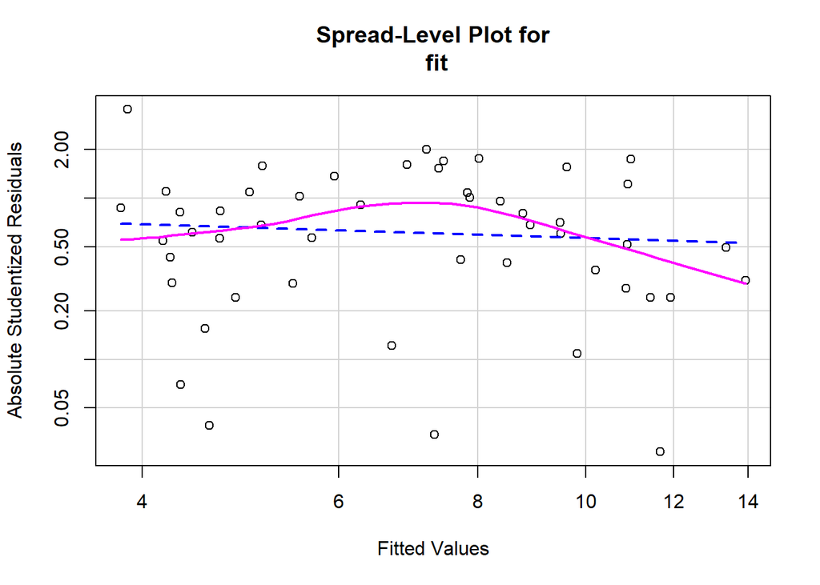

```
##
## Suggested power transformation:  1.209626
```

```r
spreadLevelPlot(fit)
```

From the result of ncvTest, p-value is $0.186 > 0.05$, thus we cannot reject the null hypothesis: the variance is constant. Additionally, the recommended power transformation 1.21 is close enough to 1, which means we do not necessarily need to perform any transformation.

Moreover, from the Spread-Level Plot above, we discover that the studentized residual is close to a horzinal line, which indicates the variance is constant.

### Global test of linear model

```r
library(gvlma)
gvmodel=gvlma(fit)
summary(gvmodel)
```

```
##
## Call:
## lm(formula = Murder ~ Population + Illiteracy + Income + Frost,
##     data = states)
##
## Residuals:
##     Min      1Q  Median      3Q     Max
## -4.7960 -1.6495 -0.0811  1.4815  7.6210
##
## Coefficients:
##              Estimate Std. Error t value Pr(>|t|)
## (Intercept) 1.235e+00  3.866e+00   0.319   0.7510
## Population  2.237e-04  9.052e-05   2.471   0.0173 *
## Illiteracy  4.143e+00  8.744e-01   4.738 2.19e-05 ***
## Income      6.442e-05  6.837e-04   0.094   0.9253
## Frost       5.813e-04  1.005e-02   0.058   0.9541
## ---
## Signif. codes:  0 '***' 0.001 '**' 0.01 '*' 0.05 '.' 0.1 ' ' 1
##
## Residual standard error: 2.535 on 45 degrees of freedom
## Multiple R-squared:  0.567,  Adjusted R-squared:  0.5285
## F-statistic: 14.73 on 4 and 45 DF,  p-value: 9.133e-08
##
##
## ASSESSMENT OF THE LINEAR MODEL ASSUMPTIONS
## USING THE GLOBAL TEST ON 4 DEGREES-OF-FREEDOM:
## Level of Significance =  0.05
##
## Call:
##  gvlma(x = fit)
##
##                     Value p-value                Decision
## Global Stat        2.7728  0.5965 Assumptions acceptable.
## Skewness           1.5374  0.2150 Assumptions acceptable.
## Kurtosis           0.6376  0.4246 Assumptions acceptable.
## Link Function      0.1154  0.7341 Assumptions acceptable.
## Heteroscedasticity 0.4824  0.4873 Assumptions acceptable.
```

### Test multicollinearity

```r
library(car)
vif(fit)
```

```
## Population Illiteracy     Income      Frost
##   1.245282   2.165848   1.345822   2.082547
```

```r
sqrt(vif(fit))>2
```

```
## Population Illiteracy     Income      Frost
##      FALSE      FALSE      FALSE      FALSE
```

$$VIF_j = \frac{1}{1-R_j^2}$$
where $R_j^2$ denotes the $R^2$ in the linear model $x_j \sim x_{all\ except\ j}$.

Obviously, if $x_j$ can be interpreted by other variable, then $R_j$ tends to be large and thus $VIF_j$ tends to be large. Generally, we maintain that $x_j$ has multicollinearity with other variables if $VIF_j > 4$.

### Test outliers

```r
library(car)
outlierTest(fit)
```

```
##        rstudent unadjusted p-value Bonferroni p
## Nevada 3.542929         0.00095088     0.047544
```

The outlierTest reports the largest absolute studentized residual.

### Test high leverage points

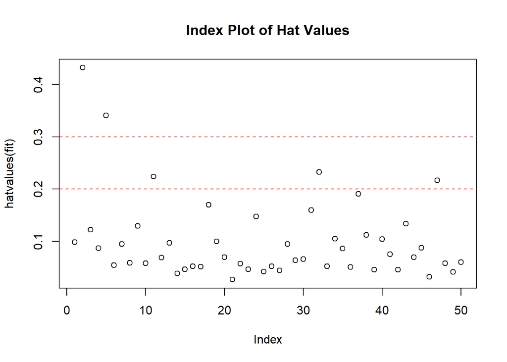

```
## integer(0)
```

```r
hat.plot <- function(fit) {
  p <- length(coefficients(fit))
  n <- length(fitted(fit))
  plot(hatvalues(fit), main="Index Plot of Hat Values")
  abline(h=c(2,3)*p/n, col="red", lty=2)
  identify(1:n, hatvalues(fit), names(hatvalues(fit)))
}
hat.plot(fit)
```

We take $2\frac{k}{n}$ and $3\frac{k}{n}$ as the judgement standard, the points whose $H_{ii}$’s are greater than the judgement standard will be considered as high leverage points.

### Test influential points

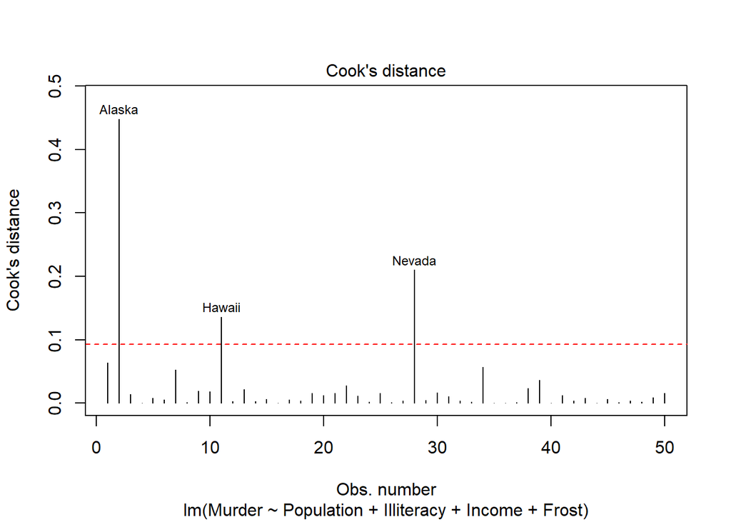

```r
cutoff <- 4/(nrow(states)-length(fit$coefficients)-2)
plot(fit, which=4, cook.levels=cutoff)
abline(h=cutoff, lty=2, col="red")
```

Remark: The Cook’s distance is defined as
$$D_i \triangleq \frac{\sum\limits_{j =
1}^n(\hat{Y_j} - \hat{Y}_{j,(i)})^2}{k\sigma^2}$$
where $\hat{Y}_{j,(i)}$ denotes the $j^{th}$ predicted value when the $i^{th}$ observation is removed from the model.

### Combination test of outliers, high leverage points and influential points.

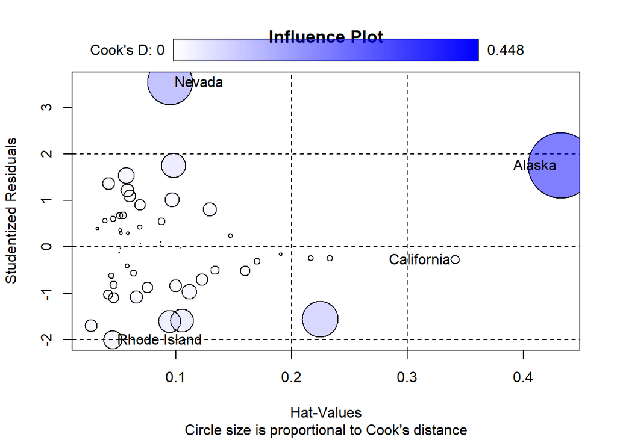

```
##                 StudRes        Hat       CookD
## Alaska        1.7536917 0.43247319 0.448050997
## California   -0.2761492 0.34087628 0.008052956
## Nevada        3.5429286 0.09508977 0.209915743
## Rhode Island -2.0001631 0.04562377 0.035858963
```

```r
influencePlot(fit, id.method="identify", main="Influence Plot",
              sub="Circle size is proportional to Cook's distance")
```

From this plot we can explicitly figure out the outliers, high leverage points and influential points.

### Test added variable

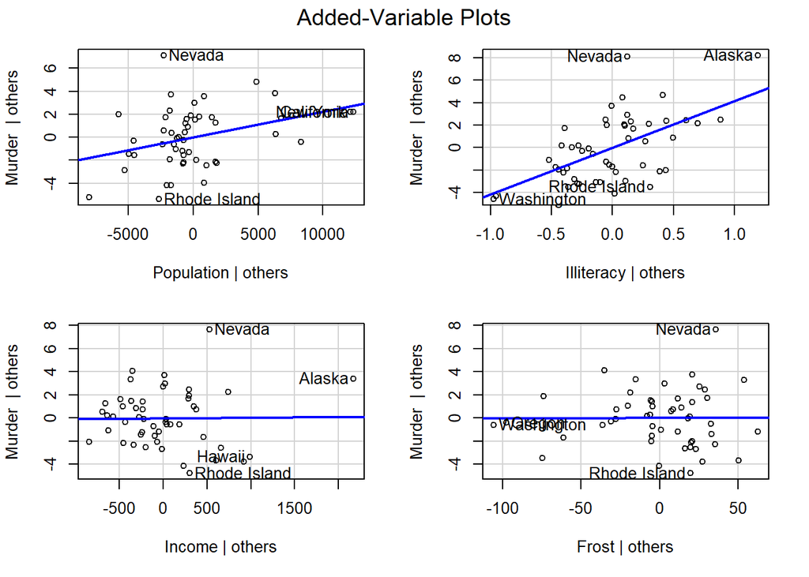

```r
avPlots(fit, ask=FALSE, onepage=TRUE, id.method="identify")
```

For each predictor $X_k$ , plot the residuals from regressing the response variable $Y$ on the other $k-1$ predictors versus the residuals from regressing $X_k$ on the other $k-1$ predictors.

My understanding: The $Y|others$ residuals represent the part of $Y$ not explained by all the variables other than $X_k$. The $X_k|others$ residuals represent the part of $X_k$ not explained by other variables. If the line is horizonal, then it follows that the other variables have already been able to fit $Y$ perfectly. Otherwise, if the line is NOT horizonal, it indicates $Y$ have NOT been learned completely by other variables, i.e., we should necessarily add $X_k$ into this model.

Moveover, The slope of the line fitted to the points in the added variable plot is equal to the regression coefficient when $Y$ is regressed on all variables including $X_k$, i.e.,

$$\begin{equation}
\begin{aligned}
& Y = \beta_0 + \beta_1 X_1 + \cdots + \beta_{k-1}X_{k-1} +
\beta_kX_k + \varepsilon_{Y|all}\\
& Y = \theta_0 + \theta_1 X_1 + \cdots + \theta_{k-1}X_{k-1} +
\varepsilon_{Y|others}\\
& X_k = \gamma_0 + \gamma_1X_1 + \cdots + \gamma_{k-1}X_{k-1} +
\varepsilon_{X_k|others}\\
\Rightarrow\ & \varepsilon_{Y|others} = 0 + \beta_k
\varepsilon_{X_k|others} + \varepsilon_{Y|all}
\end{aligned}
\end{equation}$$

Added-variable plots are so called “Partial regression plots”.

### Power transformation (for normality)

```r
summary(powerTransform(states$Murder))
```

```
## bcPower Transformation to Normality
##               Est Power Rounded Pwr Wald Lwr Bnd Wald Upr Bnd
## states$Murder    0.6055           1       0.0884       1.1227
##
## Likelihood ratio test that transformation parameter is equal to 0
##  (log transformation)
##                            LRT df     pval
## LR test, lambda = (0) 5.665991  1 0.017297
##
## Likelihood ratio test that no transformation is needed
##                            LRT df    pval
## LR test, lambda = (1) 2.122763  1 0.14512
```

### Power transformation (for linearity)

```r
boxTidwell(Murder~Population+Illiteracy,data=states)
```

```
##            MLE of lambda Score Statistic (t) Pr(>|t|)
## Population       0.86939             -0.3228   0.7483
## Illiteracy       1.35812              0.6194   0.5388
##
## iterations =  19
##
## Score test for null hypothesis that all lambdas = 1:
## F = 0.23214, df = 2 and 45, Pr(>F) = 0.7938
```

The results suggest trying transformation $Population^{0.87}$ and $Illiteracy^{1.36}$ to achieve greater linearity. But the score tests for Population $(p = 0.75)$ and Illiteracy $(p = 0.54)$ suggest that neither variable needs to be transformed.

### Model selection (ANOVA, AIC & BIC)

```r
fit1 <- lm(Murder ~ Population + Illiteracy + Income + Frost,
             data=states)
fit2 <- lm(Murder ~ Population + Illiteracy, data=states)

anova(fit2, fit1)
```

```
## Analysis of Variance Table
##
## Model 1: Murder ~ Population + Illiteracy
## Model 2: Murder ~ Population + Illiteracy + Income + Frost
##   Res.Df    RSS Df Sum of Sq      F Pr(>F)
## 1     47 289.25
## 2     45 289.17  2  0.078505 0.0061 0.9939
```

```r
AIC(fit1,fit2)
```

```
##      df      AIC
## fit1  6 241.6429
## fit2  4 237.6565
```

```r
BIC(fit1,fit2)
```

```
##      df      BIC
## fit1  6 253.1151
## fit2  4 245.3046
```